# WILD370ELKHABITATUSE

HansMartin

October 18, 2017

Load necessary packages for analysis.

Load Data

```r
elk25012<-read.csv("C:/Users/Hans Martin/Documents/ElkCollarData/GPS_Collar25012_20171018151748.csv",stringsAsFactors=FALSE)
elk25009<-read.csv("C:/Users/Hans Martin/Documents/ElkCollarData/GPS_Collar25009_20171018151418.csv",stringsAsFactors=FALSE)
elk25010<-read.csv("C:/Users/Hans Martin/Documents/ElkCollarData/GPS_Collar25010_20171018151711.csv",stringsAsFactors=FALSE)
elk25013<-read.csv("C:/Users/Hans Martin/Documents/ElkCollarData/GPS_Collar25013_20171018151812.csv",stringsAsFactors=FALSE)
elk25011<-read.csv("C:/Users/Hans Martin/Documents/ElkCollarData/GPS_Collar25011_20171018151729.csv",stringsAsFactors=FALSE)
elkdat<-do.call("rbind", list(elk25009,elk25010,elk25011,elk25012,elk25013))
```

Format the date and time to create a time stamp.

```r
elkdat$LMT24time<-format(strptime(elkdat$LMT_Time,"%I:%M:%S %p"), format="%H:%M:%S") #this function will change 12 hour time to 24 hour time.

elkdat$LMTmonth<-unlist(lapply(elkdat$LMT_Date,function(x) strsplit(x, split= "/")[[1]][1])) #extracts month
elkdat$LMTday<-unlist(lapply(elkdat$LMT_Date,function(x) strsplit(x, split= "/")[[1]][2]))#extracts day
elkdat$LMTyear<-unlist(lapply(elkdat$LMT_Date,function(x) strsplit(x, split= "/")[[1]][3]))#extracts year

elkdat$LMT24date<-paste(elkdat$LMTyear,elkdat$LMTmonth,elkdat$LMTday, sep="-") #combines date by Year-month-day
elkdat$timestamp<-paste(elkdat$LMT24date,elkdat$LMT24time,sep=" ") #creates a timestamp
#elkdat$timestamp<-strptime(elkdat$timestamp,format="%Y-%m-%d %H:%M:%S")
elkdat$LMTtimestamp<-as.POSIXlt(elkdat$timestamp, format="%Y-%m-%d %H:%M:%S",tz="America/Denver") #format the time stamp.
```

```r
elkdat<-elkdat[elkdat$LMTtimestamp>"2017-03-07 00:00:00 MST",]
```

Create a spatial object

```
## class       : SpatialPointsDataFrame
## features    : 2223
## extent      : 543888.2, 636790.6, 5701282, 5741800  (xmin, xmax, ymin, ymax)
## coord. ref. : +proj=utm +zone=11 +ellps=GRS80
## variables   : 57
## names       :  No, CollarID,  UTC_Date,   UTC_Time,  LMT_Date,   LMT_Time,  Origin, SCTS_Date,   SCTS_Time, ECEF_X..m., ECEF_Y..m., ECEF_Z..m., Latitude...., Longitude...., Height..m., ...
## min values  :  66,    25009, 10/1/2017, 1:00:11 AM, 10/1/2017, 1:00:11 AM, Iridium, 10/1/2017, 10:01:02 AM,   -1677128,   -3557392,    4966892,     51.46009,     -115.0221,    1247.11, ...
## max values  : 571,    25013,  9/9/2017, 9:03:00 PM,  9/9/2017, 9:03:00 PM, Iridium,  9/9/2017,  8:05:07 AM,   -1764702,   -3593458,    4992252,     51.81885,     -116.3667,    3320.03, ...
```

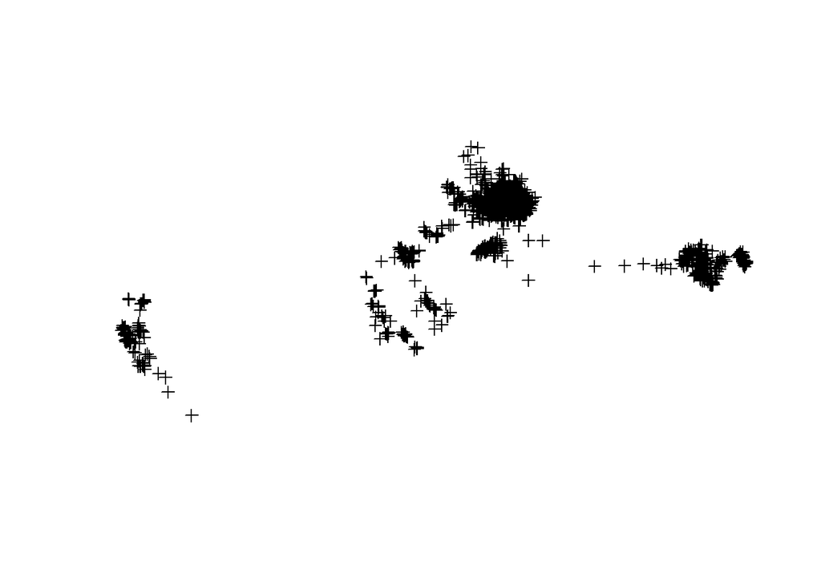

Upload the study extent

```r
studyextent<-readOGR("C:/Users/Hans Martin/Documents/R_Data/WILD370Project/YHT Study Extent/YHTstudy_extent.shp")
studyextent<-spTransform(studyextent,elkproj) #reproject using the landcover projection
elkdatspdf<-spTransform(elkdatspdf,elkproj)
```

Download the landcover type raster layer

```r
landcover16<-raster("C:/Users/Hans Martin/Documents/R_Data/WILD370Project/landcover16-20171026T151210Z-001/landcover16")
#########################################################
#clip the raster so it only covers the study area

#landcover16prj<-projectRaster(landcover16,crs=elkproj) #reproject the raster so that it matches the landcover raster
landcover16clip<-crop(x=landcover16,y=studyextent) #clip the raster so that only the study extent

writeRaster(landcover16clip, filename="landcover16clipYHTBANFF.tif", overwrite=T) #write raster so we don't need to do this step again

landcover_YHTBANFF_2016<-raster("landcover16clipYHTBANFF.tif") #load the elevation layer
```

Download the TotalForageBiomass raster layer

```r
totalbiomass16<-raster("C:/Users/Hans Martin/Documents/R_Data/WILD370Project/total16-20171027T154014Z-001/total16")
#########################################################
totalbiomass16prj<-projectRaster(totalbiomass16,crs=elkproj) #reproject the raster so that it matches the landcover raster
```

elevprj<-projectRaster(elev,crs=elkproj) #reproject the raster so that it matches the landcover raster elevclip<-crop(x=elevprj,y=studyextent) #clip the raster so that only the study extent

writeRaster(elevclip, filename=“elevationDEMYHTBANFF.tif”, overwrite=T) #write raster so we don’t need to do this step again

```r
elevationDEM<-raster("elevationDEMYHTBANFF.tif") #load the elevation layer
```

Check the CRS of all layers.

```r
proj4string(elevationDEM)
```

```
## [1] "+proj=utm +zone=11 +ellps=GRS80 +towgs84=0,0,0,0,0,0,0 +units=m +no_defs"
```

```r
proj4string(studyextent)
```

```
## [1] "+proj=utm +zone=11 +ellps=GRS80 +towgs84=0,0,0,0,0,0,0 +units=m +no_defs"
```

```r
proj4string(elkdatspdf)
```

```
## [1] "+proj=utm +zone=11 +ellps=GRS80 +towgs84=0,0,0,0,0,0,0 +units=m +no_defs"
```

```r
proj4string(landcover16)
```

```
## [1] "+proj=utm +zone=11 +ellps=GRS80 +towgs84=0,0,0,0,0,0,0 +units=m +no_defs"
```

```r
proj4string(totalbiomass16prj)
```

```
## [1] "+proj=utm +zone=11 +ellps=GRS80 +towgs84=0,0,0,0,0,0,0 +units=m +no_defs"
```

Plot the elkdat’s locations on the raster map and study area.

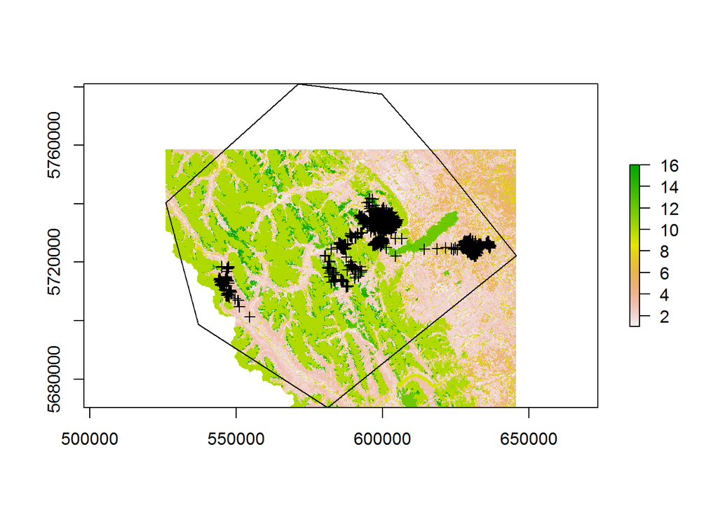

```r
plot(landcover_YHTBANFF_2016)
#plot(landcover)
plot(studyextent, add=T)
plot(elkdatspdf,add=T)
```

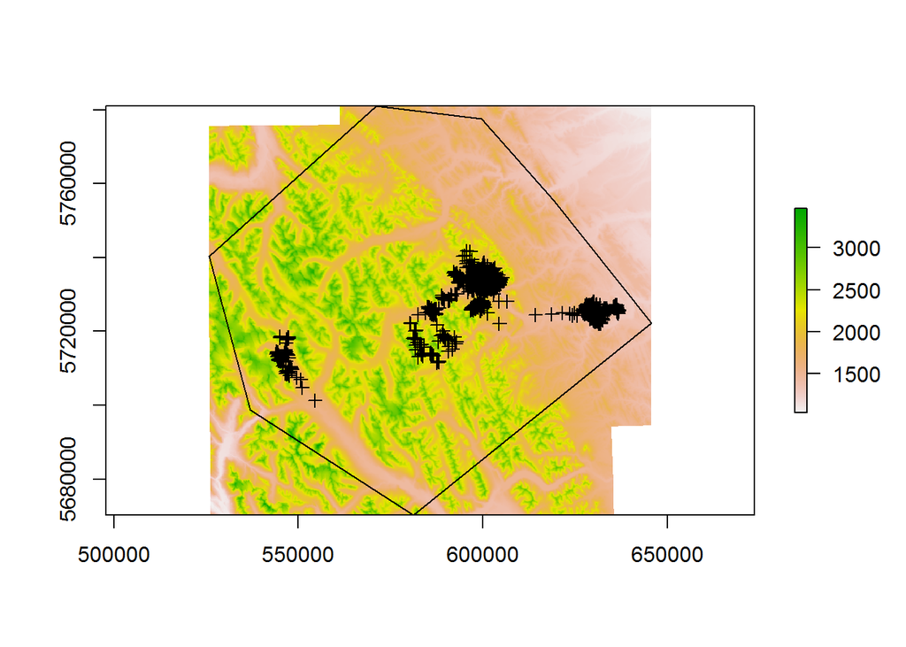

```r
plot(elevationDEM)
plot(studyextent, add=T)
plot(elkdatspdf,add=T)
```

How should we define availability of resources? Should we use the “homerange” of all of the collared elk?

```r
#calculate area for different percents of MPC
mcpareaelkdat <- mcp.area(elkdatspdf, percent=95) #area of the 95% minimum convex polygon
```

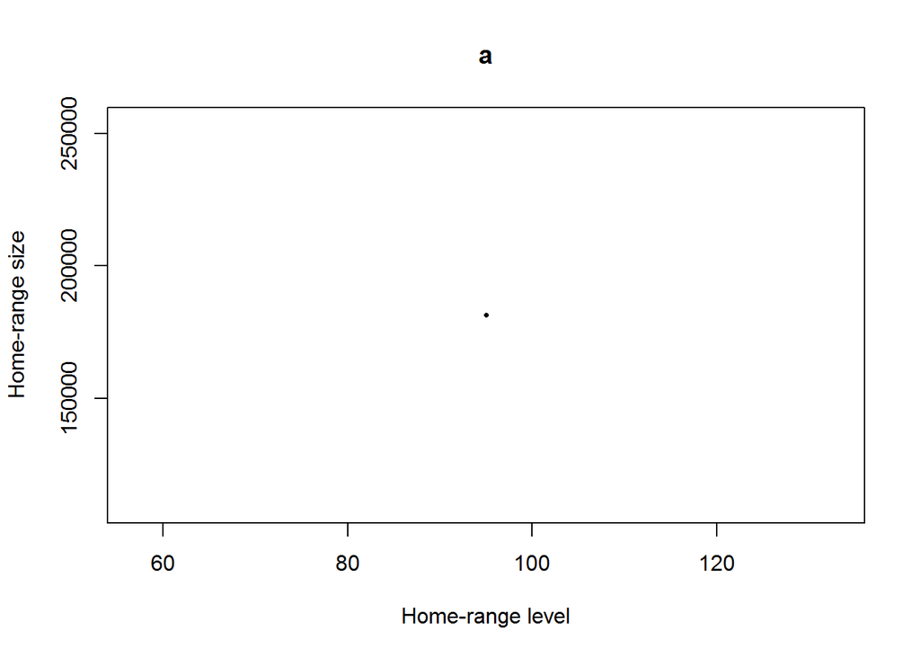

```r
mcpelkdat<-mcp(elkdatspdf, percent=95) #obtain spatial location of the mcp
#calculate 95% Kernal Density Estimate

elkdatUD <- kernelUD(elkdatspdf, grid=30, extent=0.5, same4all=TRUE) # reference grid
```

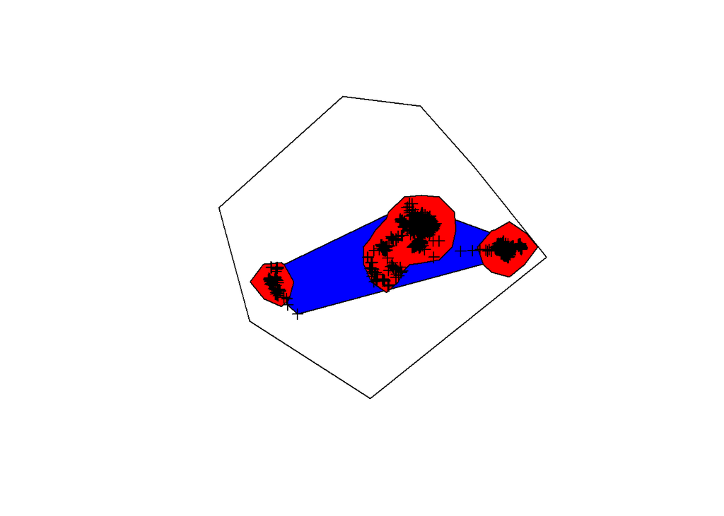

```r
#get polygons for the "home range" of all collared elk.
elkdat_KDE_95 <- getverticeshr(elkdatUD, percent=95)

#plot the 4 different methods of measuring where these animals were
plot(studyextent)
  plot(mcpelkdat,col="blue",add=T)
  plot(elkdat_KDE_95,col="red",add=T)
  plot(elkdatspdf,col="black",add=T)
```

Scale of of use: How should we define use in our study? should we define scale as the 1st, 2nd, 3rd, or 4th order? Let’s start with the 2nd order scale of use: where the homerange lies in relation to availability

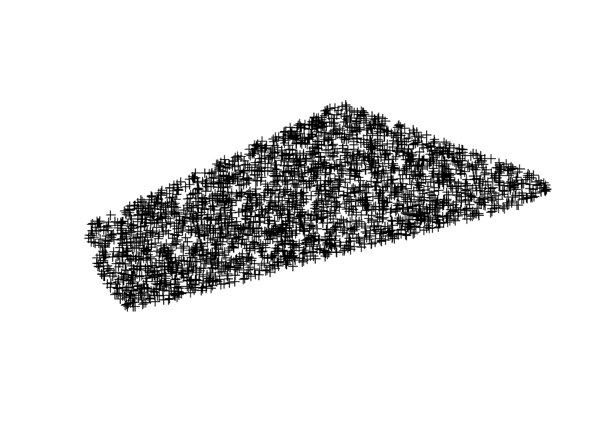

```r
#generate 3000 points from elkdata KDE polygon
mcpelkdat.avail<-spsample(mcpelkdat, 3000, "random")
plot(mcpelkdat.avail)
```

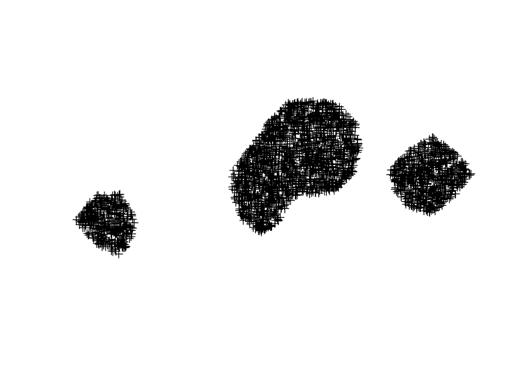

```r
#check distance between randomly sampled points is less than 30 m - this may become important later to avoid sampling the same pixels.
out.mcpelkdat.avail<- spDists(mcpelkdat.avail) #Distance from a point to the closest point
out2.mcpelkdat.avail<-ifelse(out.mcpelkdat.avail==0, NA, out.mcpelkdat.avail)#if the distance is zero remove that data point
out2.mcpelkdat.avail<-out2.mcpelkdat.avail[which(out2.mcpelkdat.avail>30)] #select only points that are greater than 30 meters from each other.

#generate 1000 points from elkdata KDE polygon
elkdat_KDE_95.avail<-spsample(elkdat_KDE_95, 3000, "random")
plot(elkdat_KDE_95.avail)
```

```r
#check distance between randomly sampled points is less than 30 m - this may become important later to avoid sampling the same pixels.
out.elkdat_KDE_95.avail<- spDists(elkdat_KDE_95.avail) #Distance from a point to the closest point
out2.elkdat_KDE_95.avail<-ifelse(out.elkdat_KDE_95.avail==0, NA, out.elkdat_KDE_95.avail)#if the distnace is zero remove that data point
which(out2.elkdat_KDE_95.avail<=30) #these may cause trouble later...
```

```
##  [1]   50569  153425 1034121 1139202 1272052 1619042 1758854 1775725
##  [9] 2559587 6123540 6224178 6359721 6360345 6533075 6603380 7208506
## [17] 7517403 7704017 8162120 8172592
```

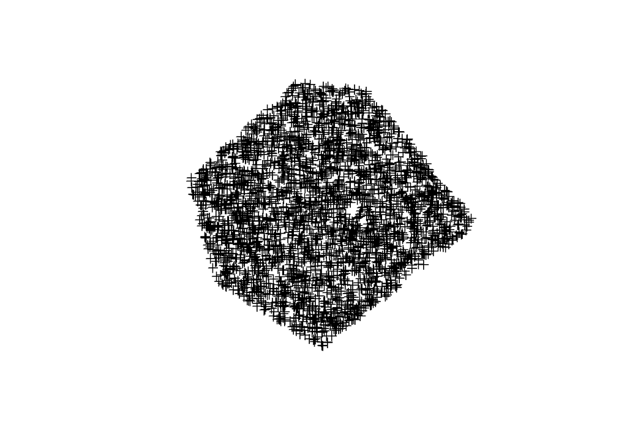

```r
#generate 1000 points from elkdata KDE polygon
elkdat_study.avail<-spsample(studyextent, 3000, "random")
plot(elkdat_study.avail)
```

```r
#check distance between randomly sampled points is less than 30 m - this may become important later to avoid sampling the same pixels.
out.elkdat_study.avail<- spDists(elkdat_study.avail) #Distance from a point to the closest point
out2.elkdat_study.avail<-ifelse(out.elkdat_study.avail==0, NA, out.elkdat_study.avail)#if the distnace is zero remove that data point
which(out2.elkdat_study.avail<=30)#select only points that are greater than 30 meters from each other.
```

```
## integer(0)
```

Extracting covariates from the rasters using all of the elk location data.

```r
#Extract covariate elevation values for all elk gps locations
elevationDEM_Elkdat<-extract(elevationDEM, elkdatspdf)

#Extract covariate landcover values for all elk gps locations
landcover_Elkdat<-extract(landcover_YHTBANFF_2016, elkdatspdf)

#Extract covariate landcover values for all elk gps locations
totalbiomass16_Elkdat<-extract(totalbiomass16prj, elkdatspdf)
```

Extracting covariates from the rasters using all of the available points from the MCP.

```r
#Extract covariate elevation values for all elk gps locations
elevationDEM_mcp_avail<-extract(elevationDEM, mcpelkdat.avail)

#Extract covariate landcover values for all elk gps locations
landcover_mcp_avail<-extract(landcover_YHTBANFF_2016, mcpelkdat.avail)

#Extract covariate landcover values for all elk gps locations
totalbiomass16_mcp_avail<-extract(totalbiomass16prj, mcpelkdat.avail)
```

Extracting covariates from the rasters using all of the available points from the KDE.

```r
#Extract covariate elevation values for all elk gps locations
elevationDEM_kde_avail<-extract(elevationDEM, elkdat_KDE_95.avail)

#Extract covariate landcover values for all elk gps locations
landcover_kde_avail<-extract(landcover_YHTBANFF_2016, elkdat_KDE_95.avail)
#Extract covariate landcover values for all elk gps locations
totalbiomass16_kde_avail<-extract(totalbiomass16prj, elkdat_KDE_95.avail)
```

Extracting covariates from the rasters using all of the available points from the study area.

```r
#Extract covariate elevation values for all elk gps locations
elevationDEM_study_avail<-extract(elevationDEM, elkdat_study.avail)

#Extract covariate landcover values for all elk gps locations
landcover_study_avail<-extract(landcover_YHTBANFF_2016, elkdat_study.avail)

#Extract covariate landcover values for all elk gps locations
totalbiomass16_study_avail<-extract(totalbiomass16prj, elkdat_study.avail)
```

Create 3 data sets with availability being defined by the study area, the mcp, and the kde.

```r
## repeat for Bow Valley pack
elkused <- data.frame(Easting=elkdatspdf@coords[,1], Northing=elkdatspdf@coords[,2], elevation=elevationDEM_Elkdat,landcover=landcover_Elkdat,totalbiomass=totalbiomass16_Elkdat, elkid=elkdatspdf$CollarID, Date=elkdatspdf$LMTtimestamp, used=1)
elkused$summer<-0 #add a summer vs winter variable
elkused$summer[elkused$Date>=as.POSIXlt("2017-05-15", format="%Y-%m-%d") & elkused$Date<=as.POSIXlt("2017-10-15", format="%Y-%m-%d")]<-1 #add a summer vs winter variable
str(elkused)
```

```
## 'data.frame':    2223 obs. of  9 variables:
##  $ Easting     : num  601236 600840 602803 603671 604153 ...
##  $ Northing    : num  5733057 5733107 5732361 5732213 5733381 ...
##  $ elevation   : num  1632 1615 1658 1725 1670 ...
##  $ landcover   : num  7 7 7 7 8 8 8 8 8 8 ...
##  $ totalbiomass: num  365 470 356 474 611 ...
##  $ elkid       : int  25009 25009 25009 25009 25009 25009 25009 25009 25009 25009 ...
##  $ Date        : POSIXct, format: "2017-03-07 01:00:57" "2017-03-07 12:00:53" ...
##  $ used        : num  1 1 1 1 1 1 1 1 1 1 ...
##  $ summer      : num  0 0 0 0 0 0 0 0 0 0 ...
```

```r
elkavail_kde<-data.frame(Easting=elkdat_KDE_95.avail@coords[,1],Northing=elkdat_KDE_95.avail@coords[,2],elevation=elevationDEM_kde_avail,landcover=landcover_kde_avail,totalbiomass=totalbiomass16_kde_avail, elkid=1,Date=NA, used=0, summer=NA)

elkavail_mcp<-data.frame(Easting=mcpelkdat.avail@coords[,1],Northing=mcpelkdat.avail@coords[,2],elevation=elevationDEM_mcp_avail,landcover=landcover_mcp_avail,totalbiomass=totalbiomass16_mcp_avail, elkid=1,Date=NA, used=0, summer=NA)

elkavail_studyarea<-data.frame(Easting=elkdat_study.avail@coords[,1],Northing=elkdat_study.avail@coords[,2],elevation=elevationDEM_study_avail,landcover=landcover_study_avail,totalbiomass=totalbiomass16_study_avail, elkid=1,Date=NA, used=0, summer=NA)


elkusedavail_studyarea<-rbind(elkused, elkavail_studyarea)


elkusedavail_mcp <- rbind(elkused, elkavail_mcp)



elkusedavail_kde <- rbind(elkused, elkavail_kde)



elkusedavail_kde$landcover_type= ifelse(elkusedavail_kde$landcover == 0, NA,
                            ifelse(elkusedavail_kde$landcover == 1, "Conifer",
                            ifelse(elkusedavail_kde$landcover == 2, "Conifer",
                            ifelse(elkusedavail_kde$landcover == 3, "Conifer",
                            ifelse(elkusedavail_kde$landcover == 4, "Deciduous",
                            ifelse(elkusedavail_kde$landcover == 5, "Mixed",
                            ifelse(elkusedavail_kde$landcover == 6, "Regen",
                            ifelse(elkusedavail_kde$landcover == 7, "Herbaceous",
                            ifelse(elkusedavail_kde$landcover == 8, "Shrub",
                            ifelse(elkusedavail_kde$landcover == 9, "Water",
                            ifelse(elkusedavail_kde$landcover == 10, "Rock-Ice",
                            ifelse(elkusedavail_kde$landcover == 11, NA, #cloud
                            ifelse(elkusedavail_kde$landcover == 12, "Burn",
                            ifelse(elkusedavail_kde$landcover == 13, "Burn",
                            ifelse(elkusedavail_kde$landcover == 14, "Burn",
                            ifelse(elkusedavail_kde$landcover == 15, "Alpine", "Alpine"))))))))))))))))
elkusedavail_mcp$landcover_type= ifelse(elkusedavail_mcp$landcover == 0, NA,
                            ifelse(elkusedavail_mcp$landcover == 1, "Conifer",
                            ifelse(elkusedavail_mcp$landcover == 2, "Conifer",
                            ifelse(elkusedavail_mcp$landcover == 3, "Conifer",
                            ifelse(elkusedavail_mcp$landcover == 4, "Deciduous",
                            ifelse(elkusedavail_mcp$landcover == 5, "Mixed",
                            ifelse(elkusedavail_mcp$landcover == 6, "Regen",
                            ifelse(elkusedavail_mcp$landcover == 7, "Herbaceous",
                            ifelse(elkusedavail_mcp$landcover == 8, "Shrub",
                            ifelse(elkusedavail_mcp$landcover == 9, "Water",
                            ifelse(elkusedavail_mcp$landcover == 10, "Rock-Ice",
                            ifelse(elkusedavail_mcp$landcover == 11, NA, #cloud
                            ifelse(elkusedavail_mcp$landcover == 12, "Burn",
                            ifelse(elkusedavail_mcp$landcover == 13, "Burn",
                            ifelse(elkusedavail_mcp$landcover == 14, "Burn",
                            ifelse(elkusedavail_mcp$landcover == 15, "Alpine", "Alpine"))))))))))))))))
elkusedavail_studyarea$landcover_type= ifelse(elkusedavail_studyarea$landcover == 0, NA,
                            ifelse(elkusedavail_studyarea$landcover == 1, "Conifer",
                            ifelse(elkusedavail_studyarea$landcover == 2, "Conifer",
                            ifelse(elkusedavail_studyarea$landcover == 3, "Conifer",
                            ifelse(elkusedavail_studyarea$landcover == 4, "Deciduous",
                            ifelse(elkusedavail_studyarea$landcover == 5, "Mixed",
                            ifelse(elkusedavail_studyarea$landcover == 6, "Regen",
                            ifelse(elkusedavail_studyarea$landcover == 7, "Herbaceous",
                            ifelse(elkusedavail_studyarea$landcover == 8, "Shrub",
                            ifelse(elkusedavail_studyarea$landcover == 9, "Water",
                            ifelse(elkusedavail_studyarea$landcover == 10, "Rock-Ice",
                            ifelse(elkusedavail_studyarea$landcover == 11, NA, #cloud
                            ifelse(elkusedavail_studyarea$landcover == 12, "Burn",
                            ifelse(elkusedavail_studyarea$landcover == 13, "Burn",
                            ifelse(elkusedavail_studyarea$landcover == 14, "Burn",
                            ifelse(elkusedavail_studyarea$landcover == 15, "Alpine", "Alpine"))))))))))))))))

# elkusedavail_studyarea$landcover_type= ifelse(elkusedavail_studyarea$landcover == 0, NA,
#                             ifelse(elkusedavail_studyarea$landcover == 1, "Open Conifer",
#                             ifelse(elkusedavail_studyarea$landcover == 2, "Moderate Conifer",
#                             ifelse(elkusedavail_studyarea$landcover == 3, "Closed Conifer",
#                             ifelse(elkusedavail_studyarea$landcover == 4, "Deciduous",
#                             ifelse(elkusedavail_studyarea$landcover == 5, "Mixed",
#                             ifelse(elkusedavail_studyarea$landcover == 6, "Regen",
#                             ifelse(elkusedavail_studyarea$landcover == 7, "Herbaceous",
#                             ifelse(elkusedavail_studyarea$landcover == 8, "Shrub",
#                             ifelse(elkusedavail_studyarea$landcover == 9, "Water",
#                             ifelse(elkusedavail_studyarea$landcover == 10, "Rock-Ice",
#                             ifelse(elkusedavail_studyarea$landcover == 11, NA, #cloud
#                             ifelse(elkusedavail_studyarea$landcover == 12, "Burn-Forest",
#                             ifelse(elkusedavail_studyarea$landcover == 13, "Burn-Grassland",
#                             ifelse(elkusedavail_studyarea$landcover == 14, "Burn-Shrub",
#                             ifelse(elkusedavail_studyarea$landcover == 15, "Alpine Herb", "Alpine Shrub"))))))))))))))))
elkusedavail_kdecomplete<-elkusedavail_kde[complete.cases(elkusedavail_kde[,1:5]),]
elkusedavail_studyareacomplete<-elkusedavail_studyarea[complete.cases(elkusedavail_studyarea[,1:5]),]
elkusedavail_mcpcomplete<-elkusedavail_mcp[complete.cases(elkusedavail_mcp[,1:5]),]
elkusedavail_kdecomplete<-elkusedavail_kde[complete.cases(elkusedavail_kde[,10]),]
elkusedavail_studyareacomplete<-elkusedavail_studyarea[complete.cases(elkusedavail_studyarea[,10]),]
elkusedavail_mcpcomplete<-elkusedavail_mcp[complete.cases(elkusedavail_mcp[,10]),]

#save our data to csv files
write.csv(elkusedavail_studyareacomplete, "elkused_avail_studyarea.csv")
write.csv(elkusedavail_mcpcomplete, "elkused_avail_mcp.csv")
write.csv(elkusedavail_kdecomplete, "elkusedavail_kde.csv")
```

```r
elkusedavail_studyareacomplete<-read.csv("elkused_avail_studyarea.csv")
elkusedavail_mcpcomplete<-read.csv( "elkused_avail_mcp.csv")
elkusedavail_kdecomplete<-read.csv( "elkusedavail_kde.csv")
```

# Lets plot the used vs available points using a minimum convex polygon as our “available” locations

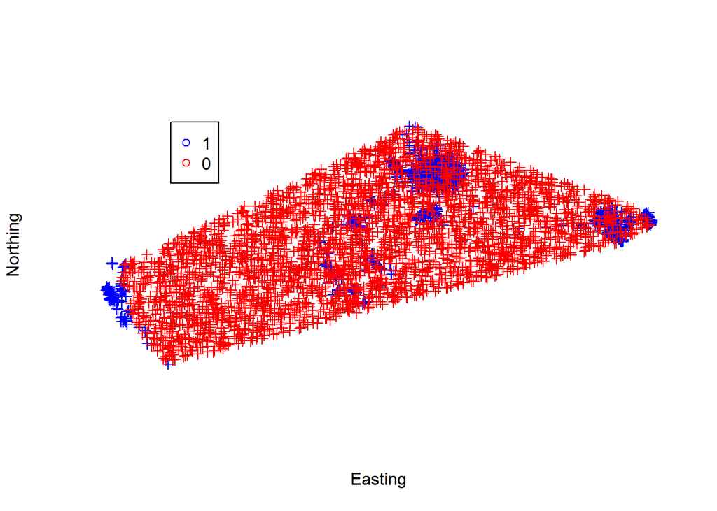

```r
coordsmcp<-cbind(elkusedavail_mcpcomplete$Easting,elkusedavail_mcpcomplete$Northing)
datamcp<-elkusedavail_mcpcomplete
spmcp=SpatialPoints(coordsmcp,CRS("+proj=utm +zone=11 +ellps=GRS80 +towgs84=0,0,0,0,0,0,0 +units=m +no_defs"))
elkused_avail_mcp_spdf<-SpatialPointsDataFrame(spmcp,datamcp)
# lets plot them all together, used and home-range level availability
plot(elkused_avail_mcp_spdf,col=c("red","blue")[as.factor(elkused_avail_mcp_spdf$used)], ylab="Northing",xlab="Easting")
legend(555000,5742500,unique(as.factor(elkused_avail_mcp_spdf$used)),col=c("blue","red"),pch=1)
```

#Lets plot the used vs available points using a 95% isopleths of kernel density as our “available” locations

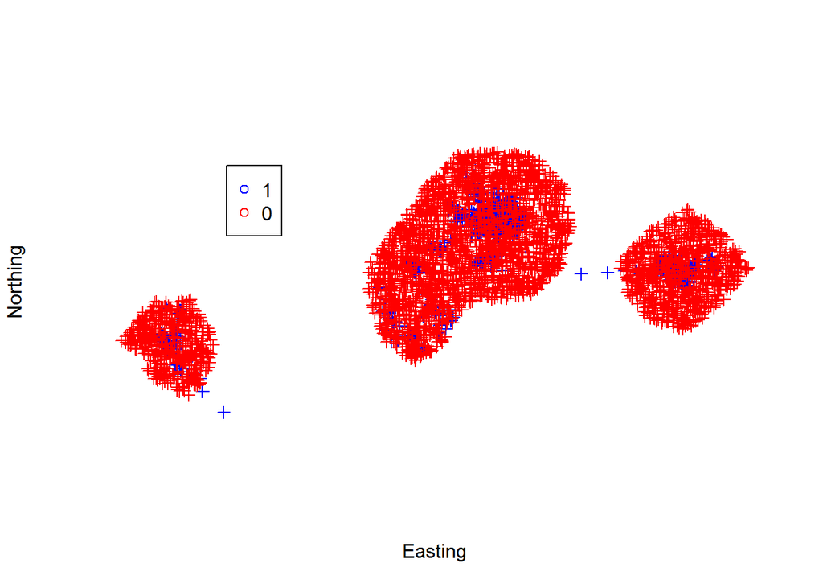

```r
coordskde<-cbind(elkusedavail_kdecomplete$Easting,elkusedavail_kdecomplete$Northing) #coordinates
datakde<-elkusedavail_kdecomplete #data that corresponds to the coordinates above
spkde=SpatialPoints(coordskde,CRS("+proj=utm +zone=11 +ellps=GRS80 +towgs84=0,0,0,0,0,0,0 +units=m +no_defs"))
elkused_avail_kde_spdf<-SpatialPointsDataFrame(spkde,datakde)
# lets plot them all together, used and home-range level availability
plot(elkused_avail_kde_spdf,col=c("red","blue")[as.factor(elkused_avail_kde_spdf$used)], ylab="Northing",xlab="Easting")
legend(555000,5742500,unique(elkused_avail_kde_spdf$used),col=c("blue","red"),pch=1)
```

# Lets plot the used vs available points using the whole study area as our “available” locations

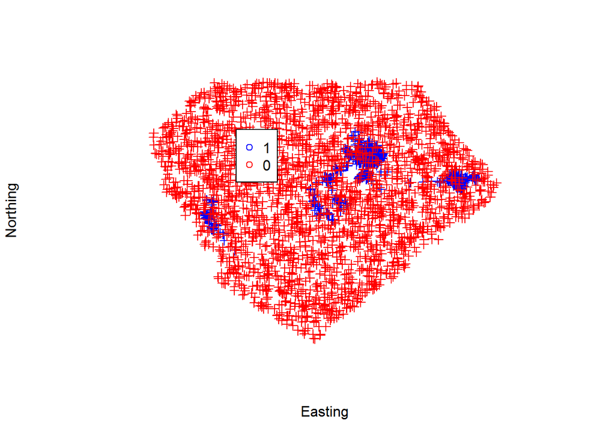

```r
coordsstudy<-cbind(elkusedavail_studyareacomplete$Easting,elkusedavail_studyareacomplete$Northing)
datastudy<-elkusedavail_studyareacomplete
spstudy=SpatialPoints(coordsstudy,CRS("+proj=utm +zone=11 +ellps=GRS80 +towgs84=0,0,0,0,0,0,0 +units=m +no_defs"))
elkused_avail_study_spdf<-SpatialPointsDataFrame(spstudy,datastudy)
# lets plot them all together, used and home-range level availability
plot(elkused_avail_study_spdf,col=c("red","blue")[as.factor(elkused_avail_study_spdf$used)], ylab="Northing",xlab="Easting")
legend(555000,5742500,unique(elkused_avail_study_spdf$used),col=c("blue","red"),pch=1)
```

Finally! Lets look at Habitat selection!!

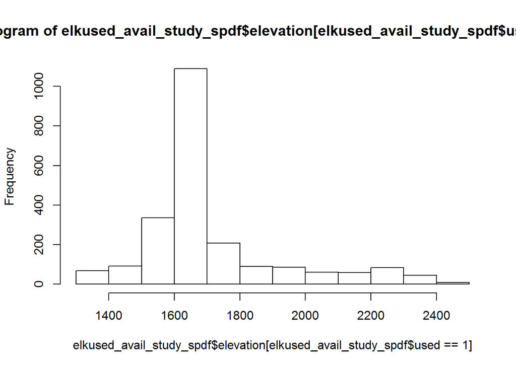

```r
# graphing manually in R
hist(elkused_avail_study_spdf$elevation[elkused_avail_study_spdf$used==1]) #create a frequency histogram of elevation at used locations.
```

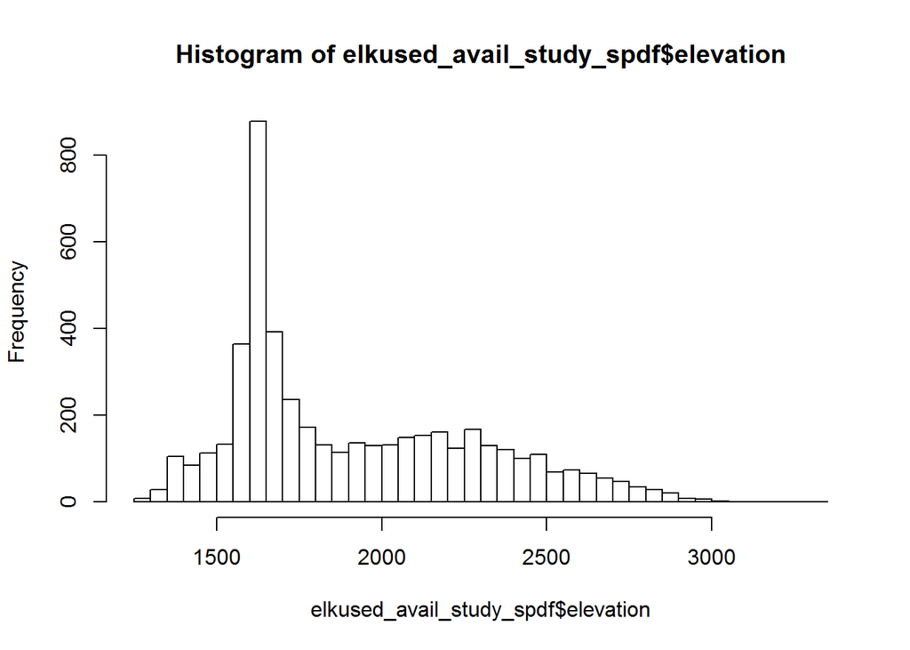

```r
# change width of bins for histogram
hist(elkused_avail_study_spdf$elevation, breaks = 50)
```

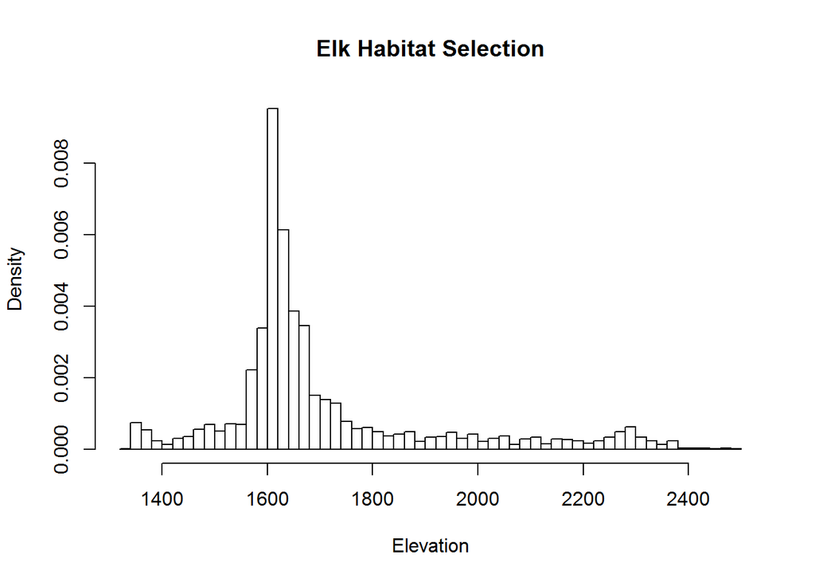

```r
## add text and stuff
hist(elkused_avail_study_spdf$elevation[elkused_avail_study_spdf$used==1], breaks = 50, probability = TRUE, main="Elk Habitat Selection", xlab="Elevation") #probability =true changes the historgram from a frequency historgram to a density curve.
```

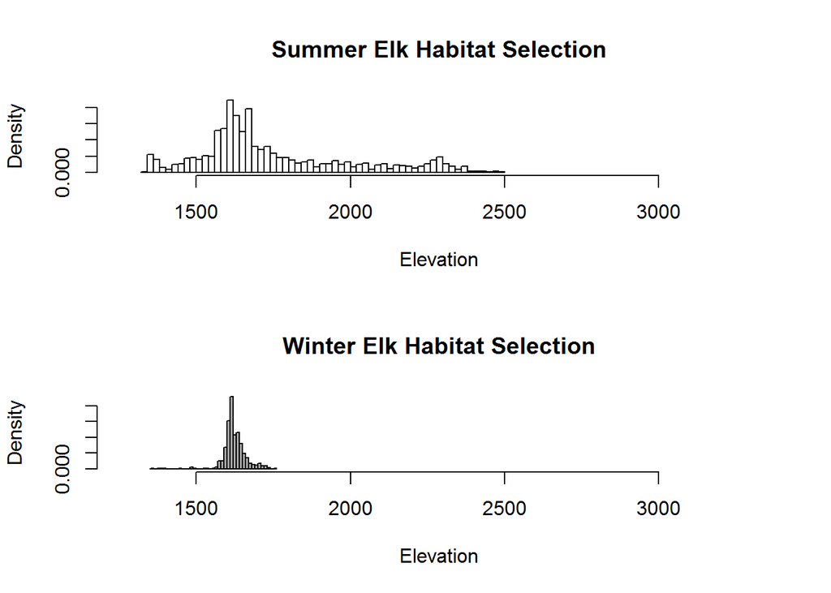

```r
# Plot summer use of elevation
par(mfrow=c(2,1)) #mfrow=c(number of rows, number of columns) this function is used to combine two plots into one figure
hist(elkusedavail_studyareacomplete$elevation[elkusedavail_studyareacomplete$used==1 & elkusedavail_studyareacomplete$summer==1],breaks=50, xlim = c(min(elkusedavail_studyareacomplete$elevation),max(elkusedavail_studyareacomplete$elevation)), probability = TRUE, main="Summer Elk Habitat Selection", xlab="Elevation")


# Plot winter use of elevation
hist(elkusedavail_studyareacomplete$elevation[elkusedavail_studyareacomplete$used==1 & elkusedavail_studyareacomplete$summer==0],breaks=50,col="darkgray",xlim = c(min(elkusedavail_studyareacomplete$elevation),max(elkusedavail_studyareacomplete$elevation)), probability =TRUE,main="Winter Elk Habitat Selection", xlab="Elevation")
```

(another way that you can plot the use of elevation side by side)

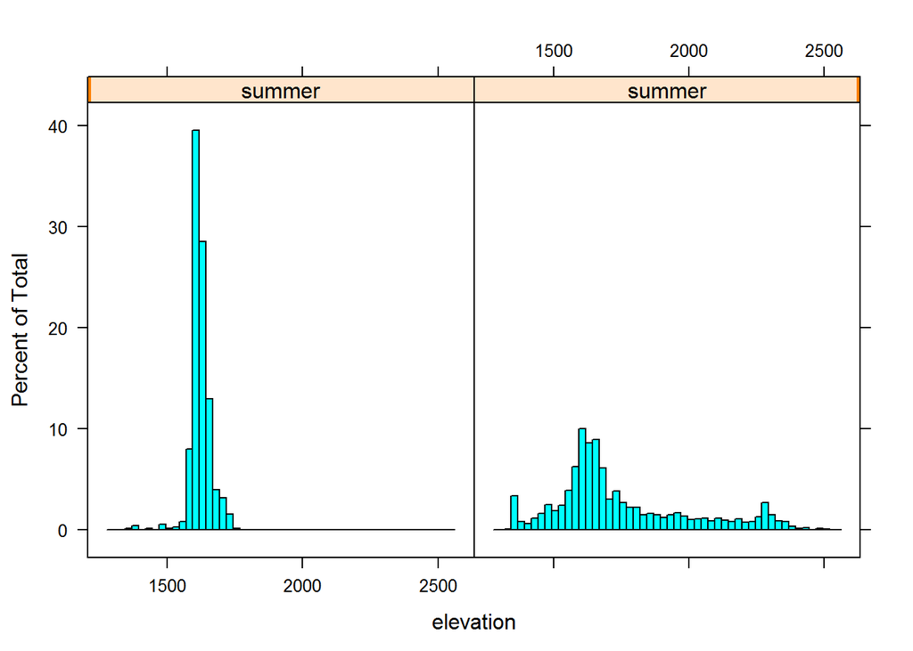

```r
## another way to make a similar graph
histogram(~elevation|summer, data = elkusedavail_studyareacomplete[elkusedavail_studyareacomplete$used==1,], nint = 50)
```

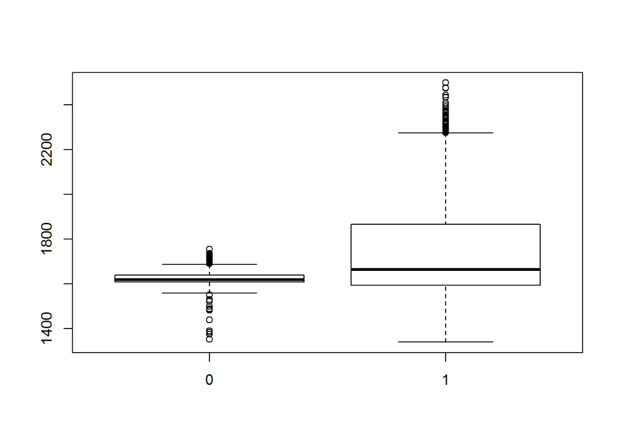

```r
boxplot(elevation~summer, data=elkusedavail_studyareacomplete[elkusedavail_studyareacomplete$used==1,], id.method="y")
```

## QUESTION: what can you tell about the use of elevation for elk between summer and winter???

Lets now look at how elk used different landcover types. we will start by looking at the overall “yearly” use of habitat types.

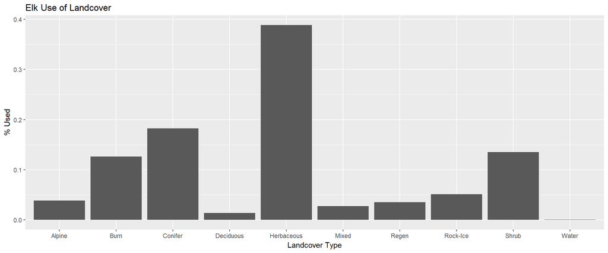

```r
ggplot(
  elkusedavail_studyareacomplete[elkusedavail_studyareacomplete$used==1,],
    aes(x=landcover_type)
  )+
    geom_bar(
      aes(
        y=(..count..)/sum(..count..)
        )
      )+
  ggtitle("Elk Use of Landcover") +
  labs(x="Landcover Type",y="% Used")
```

Lets now look at how elk uselandcover types in summer vs winter.

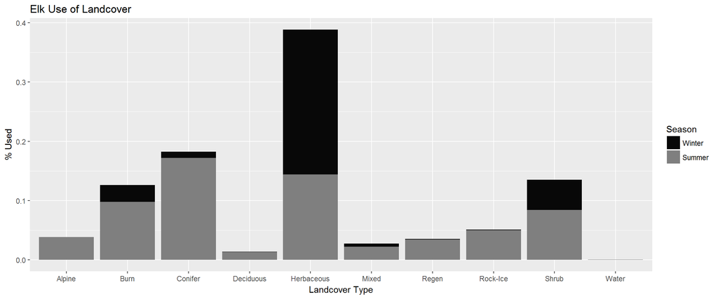

```r
ggplot(
  elkusedavail_studyareacomplete[elkusedavail_studyareacomplete$used==1,], #data to be used
    aes(
      x=landcover_type, #column in the dataframe with categorical data
      fill=as.factor(summer) #compares summer to winter values
      )
  )+
    geom_bar(
      aes(
        y=(..count..)/sum(..count..), #column in the dataframe with categorical data
        fill=as.factor(summer) # this equation plots the % use instead of frequency
        )
    )+

  ggtitle("Elk Use of Landcover") + #title of the plot
  labs(x="Landcover Type", #label of the x-axis
       y="% Used", #label of the y axis
       fill = "Season")+ #labels the "fill" variable
  scale_fill_manual(labels = c("Winter", "Summer"), #labels the fill variables
                    values = c("grey3", "grey50")#Specifying the colors of the bars
                    )
```

Lets now compare how elk uselandcover types compared to their availability.

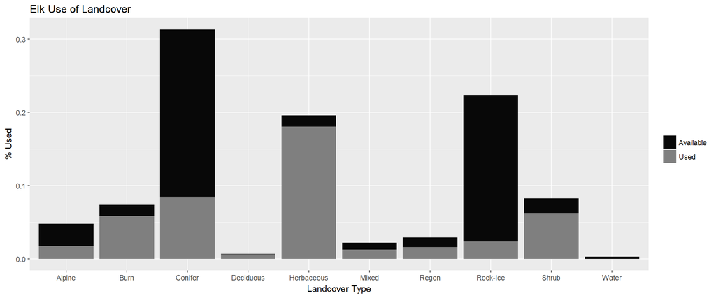

```r
ggplot(
  elkusedavail_studyareacomplete, #data to be used
    aes(
      x=landcover_type, #column in the dataframe with categorical data
      fill=as.factor(used) #compares summer to winter values
      )
  )+
    geom_bar(
      aes(
        y=(..count..)/sum(..count..) #column in the dataframe with categorical data
        #fill=as.factor(summer) # this equation plots the % use instead of frequency
        )
    )+

  ggtitle("Elk Use of Landcover") +
  labs(x="Landcover Type",y="% Used",fill = "")+
  scale_fill_manual(labels = c("Available", "Used"), values = c("grey3", "grey50"))
```

Lets actually look at the selection ratios to see what landcover elk are selecting.

```r
#names.m = data.frame(unique(elkusedavail_studyareacomplete$landcover),unique(elkusedavail_studyareacomplete$landcover_type))
# Now I put it order
#names.m = names.m[order(names.m)[1:15],]
#names.m
elkusedavail_studyareacomplete$used_factor<-as.factor(elkusedavail_studyareacomplete$used)
# Define a factor variable, landcov.f,
# the sorted table makes defining the names of your factor level easy!
#Note that there are many alternative ways of defining your landcover/habitattype
# as a factor. This method seemed most explicit in terms of defining the design matrix
#elkusedavail_studyareacomplete$landcov.f=factor(elkusedavail_studyareacomplete$landcover,labels = #names.m$unique.elkusedavail_studyareacomplete.landcover_type.)


# Univariate Selection Ratio's
landcovSelection_studyarea <-table(elkusedavail_studyareacomplete$landcover_type, elkusedavail_studyareacomplete$used_factor)

# Univariate Selection Ratio's


landcovSelection2 <- as.data.frame.matrix(landcovSelection_studyarea) #creates a matrix from the dataframe
colnames(landcovSelection2)[1:2] <- c("avail","used") #label the columns in the matrix
landcovSelection2$selection <-
  (
    (landcovSelection2$used #number of used locations for the corresponding line of landcover type
   / sum(
    landcovSelection2$used #total number of used locations
    )
  )
/
  (landcovSelection2$avail/ #number of available locations for the corresopnding line of landcover type
     sum(
       landcovSelection2$avail #total number of available locations
       )
   )
)
landcovSelection2$lnSelection <- log(landcovSelection2$selection)
landcovSelection2
```

```
##            avail used   selection lnSelection
## Alpine       144   86  0.68829660  -0.3735354
## Burn          73  281  4.43632263   1.4898258
## Conifer     1094  406  0.42770899  -0.8493123
## Deciduous      2   31 17.86369771   2.8827706
## Herbaceous    74  864 13.45617682   2.5994382
## Mixed         45   61  1.56227320   0.4461419
## Regen         63   78  1.42690058   0.3555047
## Rock-Ice     958  114  0.13714469  -1.9867188
## Shrub         95  301  3.65159457   1.2951639
## Water         14    1  0.08232119  -2.4971268
```

```r
write.table(landcovSelection2, "1storderelkselection.csv", sep=",", row.names = TRUE, col.names=TRUE)
```

Now lets look at 3rd order selection.

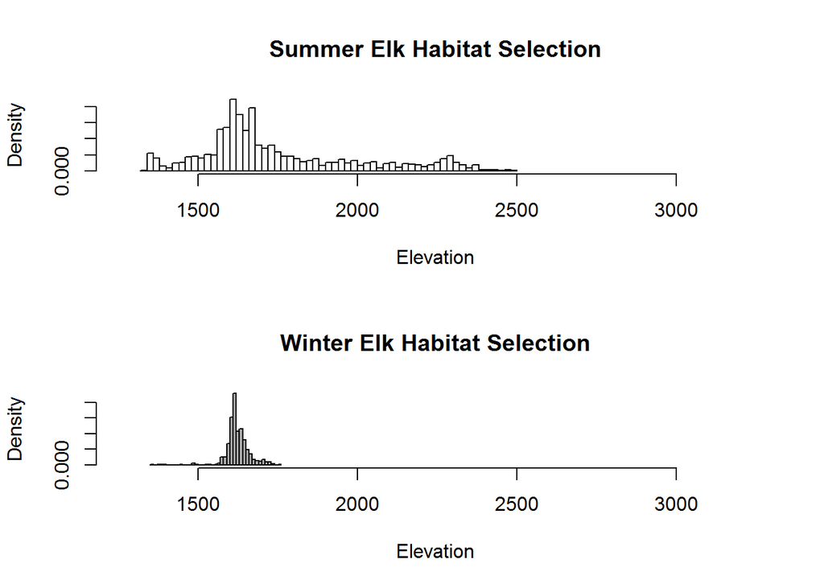

```r
# Plot summer use of elevation
par(mfrow=c(2,1)) #mfrow=c(number of rows, number of columns) this function is used to combine two plots into one figure
hist(elkusedavail_kdecomplete$elevation[elkusedavail_kdecomplete$used==1 & elkusedavail_kdecomplete$summer==1],breaks=50, xlim = c(min(elkusedavail_kdecomplete$elevation),max(elkusedavail_kdecomplete$elevation)), probability = TRUE, main="Summer Elk Habitat Selection", xlab="Elevation")


# Plot winter use of elevation
hist(elkusedavail_kdecomplete$elevation[elkusedavail_kdecomplete$used==1 & elkusedavail_kdecomplete$summer==0],breaks=50,col="darkgray",xlim = c(min(elkusedavail_kdecomplete$elevation),max(elkusedavail_kdecomplete$elevation)), probability =TRUE,main="Winter Elk Habitat Selection", xlab="Elevation")
```

(another way that you can plot the use of elevation side by side)

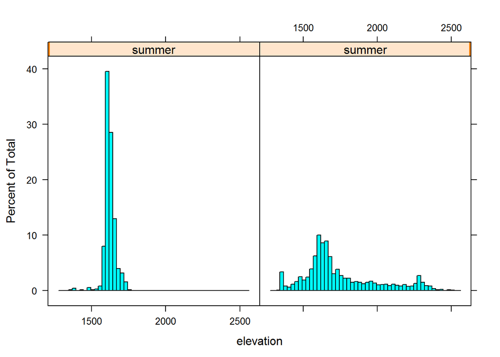

```r
## another way to make a similar graph
histogram(~elevation|summer, data = elkusedavail_kdecomplete[elkusedavail_kdecomplete$used==1,], nint = 50)
```

## QUESTION: what can you tell about the use of elevation for elk between summer and winter???

Lets now look at how elk used different landcover types. we will start by looking at the overall “yearly” use of habitat types.

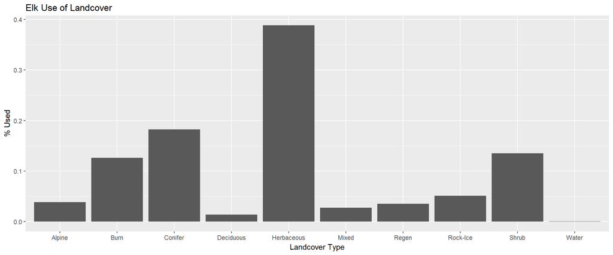

```r
ggplot(
  elkusedavail_kdecomplete[elkusedavail_kdecomplete$used==1,],
    aes(x=landcover_type)
  )+
    geom_bar(
      aes(
        y=(..count..)/sum(..count..)
        )
      )+
  ggtitle("Elk Use of Landcover") +
  labs(x="Landcover Type",y="% Used")
```

Lets now look at how elk uselandcover types in summer vs winter.

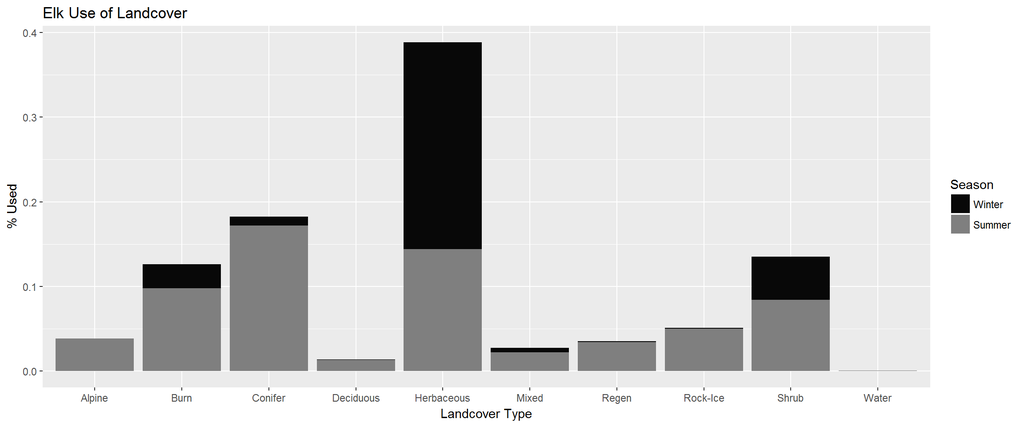

```r
ggplot(
  elkusedavail_kdecomplete[elkusedavail_kdecomplete$used==1,], #data to be used
    aes(
      x=landcover_type, #column in the dataframe with categorical data
      fill=as.factor(summer) #compares summer to winter values
      )
  )+
    geom_bar(
      aes(
        y=(..count..)/sum(..count..), #column in the dataframe with categorical data
        fill=as.factor(summer) # this equation plots the % use instead of frequency
        )
    )+

  ggtitle("Elk Use of Landcover") + #title of the plot
  labs(x="Landcover Type", #label of the x-axis
       y="% Used", #label of the y axis
       fill = "Season")+ #labels the "fill" variable
  scale_fill_manual(labels = c("Winter", "Summer"), #labels the fill variables
                    values = c("grey3", "grey50")#Specifying the colors of the bars
                    )
```

Lets now compare how elk uselandcover types compared to their availability.

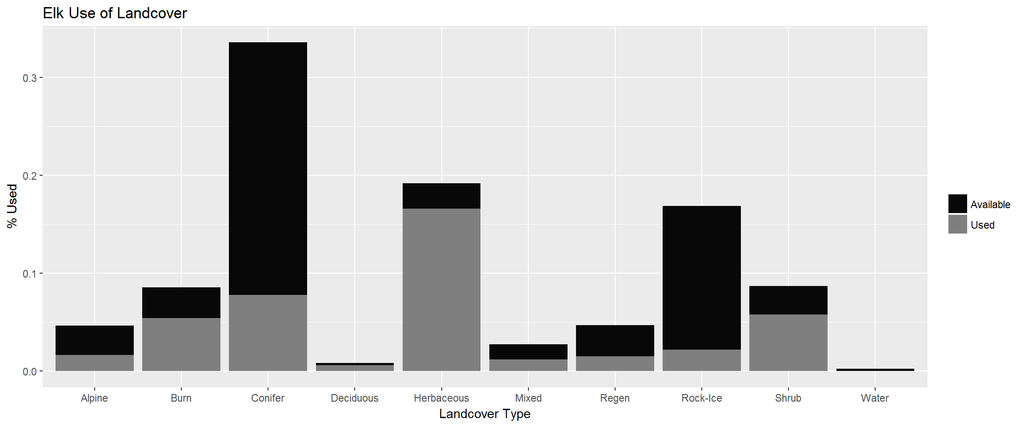

```r
ggplot(
  elkusedavail_kdecomplete, #data to be used
    aes(
      x=landcover_type, #column in the dataframe with categorical data
      fill=as.factor(used) #compares summer to winter values
      )
  )+
    geom_bar(
      aes(
        y=(..count..)/sum(..count..) #column in the dataframe with categorical data
        #fill=as.factor(summer) # this equation plots the % use instead of frequency
        )
    )+

  ggtitle("Elk Use of Landcover") +
  labs(x="Landcover Type",y="% Used",fill = "")+
  scale_fill_manual(labels = c("Available", "Used"), values = c("grey3", "grey50"))
```

Lets actually look at the selection ratios to see what landcover elk are selecting.

```r
#names.m = data.frame(unique(elkusedavail_kdecomplete$landcover),unique(elkusedavail_kdecomplete$landcover_type))
# Now I put it order
#names.m = names.m[order(names.m)[1:15],]
#names.m

# Define a factor variable, landcov.f,
# the sorted table makes defining the names of your factor level easy!
#Note that there are many alternative ways of defining your landcover/habitattype
# as a factor. This method seemed most explicit in terms of defining the design matrix
#elkusedavail_kdecomplete$landcov.f=factor(elkusedavail_kdecomplete$landcover,labels = names.m$unique.elkusedavail_kdecomplete.landcover_type.)

elkusedavail_kdecomplete$used_factor<-as.factor(elkusedavail_kdecomplete$used)
# Univariate Selection Ratio's
landcovSelection_kde <-table(elkusedavail_kdecomplete$landcover_type, elkusedavail_kdecomplete$used_factor)

# Univariate Selection Ratio's


landcovSelection2 <- as.data.frame.matrix(landcovSelection_kde) #creates a matrix from the dataframe
colnames(landcovSelection2)[1:2] <- c("avail","used") #label the columns in the matrix
landcovSelection2$PercentUse <-

    (landcovSelection2$used #number of used locations for the corresponding line of landcover type
   / sum(
    landcovSelection2$used #total number of used locations
    )
  )
  landcovSelection2$PercentAvailable <-
  (landcovSelection2$avail/ #number of available locations for the corresopnding line of landcover type
     sum(
       landcovSelection2$avail #total number of available locations
       )
   )

landcovSelection2$selection <-
  (
    (landcovSelection2$used #number of used locations for the corresponding line of landcover type
   / sum(
    landcovSelection2$used #total number of used locations
    )
  )
/
  (landcovSelection2$avail/ #number of available locations for the corresopnding line of landcover type
     sum(
       landcovSelection2$avail #total number of available locations
       )
   )
)
landcovSelection2$lnSelection <- log(landcovSelection2$selection)
landcovSelection2
```

```
##            avail used   PercentUse PercentAvailable selection
## Alpine       155   86 0.0386864597      0.051874163 0.7457751
## Burn         165  281 0.1264057580      0.055220884 2.2890934
## Conifer     1344  406 0.1826360774      0.449799197 0.4060391
## Deciduous     13   31 0.0139451192      0.004350736 3.2052320
## Herbaceous   135  864 0.3886639676      0.045180723 8.6024291
## Mixed         82   61 0.0274403959      0.027443106 0.9999013
## Regen        167   78 0.0350877193      0.055890228 0.6277970
## Rock-Ice     764  114 0.0512820513      0.255689424 0.2005638
## Shrub        151  301 0.1354026091      0.050535475 2.6793576
## Water         12    1 0.0004498426      0.004016064 0.1120108
##              lnSelection
## Alpine     -0.2933311884
## Burn        0.8281558277
## Conifer    -0.9013057292
## Deciduous   1.1647844793
## Herbaceous  2.1520446227
## Mixed      -0.0000987508
## Regen      -0.4655383534
## Rock-Ice   -1.6066227085
## Shrub       0.9855770602
## Water      -2.1891600175
```

```r
write.table(landcovSelection2, "3rdorderelkselection.csv", sep=",", row.names = TRUE, col.names=TRUE)
```